# Annotated EMP Analysis

# Part 2: Silking

### Run some simple models

This step establishes “parental” and environmental base levels that can be compared to.

```r
base <- lm(simulated.phenotype ~ location + Parent1, data=allParents)
Parents_coefficients <- base$coefficients[3:length(base$coefficients)]
names(Parents_coefficients) <- unlist(strsplit(names(Parents_coefficients),split="Parent1"))[seq(2,length(Parents_coefficients)*2,2)]

All_EMPs$location <- factor(All_EMPs$location,levels = c("location1","location2"))
emps_loc <- lm(simulated.phenotype ~ location, data = All_EMPs,na.action=na.exclude) #note na.action=na.exclude to keep NA values in residuals
Loc_coef <- emps_loc$coefficients[2]
Predicted_locs <- All_EMPs$simulated.phenotype
Predicted_locs[which(All_EMPs$location=="location2")] <- Predicted_locs[which(All_EMPs$location=="location2")] + Loc_coef
```

### Make a data frame with various results

Here I create a “results” data frame, which includes columns for everything that will be compared in the analysis.

```r
results <- data.frame(Genotype = All_EMPs$genotype, P1 = All_EMPs$Parent1, P2 = All_EMPs$Parent2, Loc_BLUPs = Predicted_locs,stringsAsFactors = F)

Predicted = c()
for(i in 1:nrow(results)){
  Predicted[i] <- as.numeric(Parents_coefficients[results$P1[i]] + Parents_coefficients[results$P2[i]])
}

results$Predicted = Predicted

results$Deviation = results$Loc_BLUPs - results$Predicted
```

### Calculate mean deviation from expected by genotype

Here I calculate the mean deviation by genotype. In other words, this is the results matrix averaged over genotypes (instead of including a row for every plot in the field). These are the ultimate results.

```r
DeviationByGenotype <- aggregate(results$Deviation, by=list(results$Genotype),mean)
StandardDeviationByGenotype <- aggregate(results$Deviation,by=list(results$Genotype),sd)
```

### Make a pretty plot

This is the plot of EMP results. Notice that title should be recreated if trait under evaluation changes.

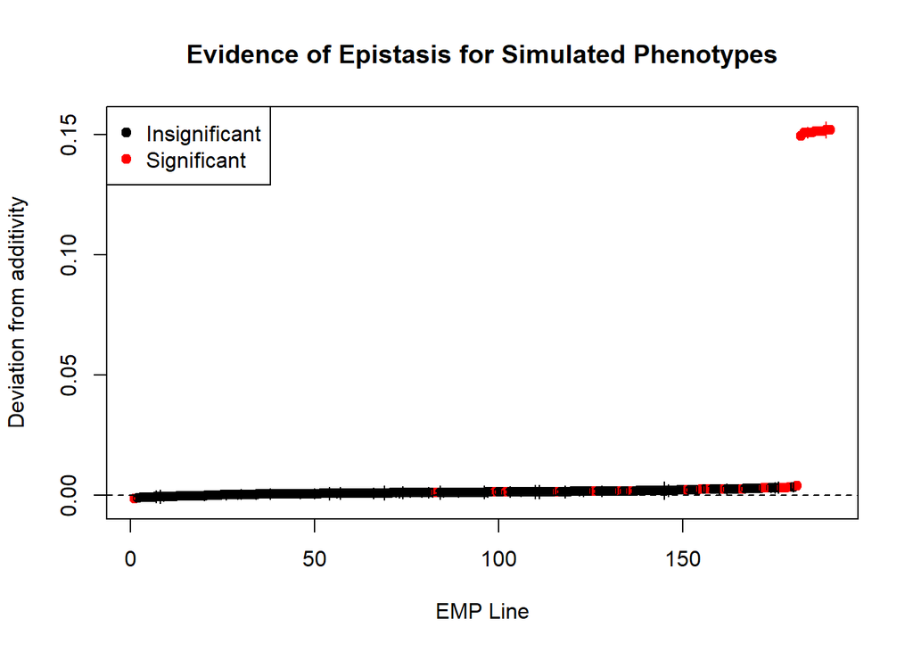

```r
ordered <- DeviationByGenotype[order(DeviationByGenotype[,2]),]
ordered$SD <-StandardDeviationByGenotype[order(DeviationByGenotype[,2]),2]
orderedNoNa <- ordered[which(is.na(ordered$x) ==F & is.na(ordered$SD) ==F),]

col <- rep("black",nrow(orderedNoNa))
col[which(orderedNoNa$x+1.96*orderedNoNa$SD < 0 | orderedNoNa$x-1.96*orderedNoNa$SD >0)]<-"red"
plot(1:nrow(orderedNoNa),orderedNoNa$x,ylim=c(min(orderedNoNa$x-orderedNoNa$SD),max(orderedNoNa$x+orderedNoNa$SD)),pch=19,col=col,ylab="Deviation from additivity",xlab="EMP Line",main=paste("Evidence of Epistasis for", trait,sep=" "))
abline(h=0,lty=2)
segments(x0=1:nrow(orderedNoNa),y0={orderedNoNa$x-orderedNoNa$SD},x1=1:nrow(orderedNoNa),y1={orderedNoNa$x+orderedNoNa$SD},col=col)
legend("topleft","c(x,y",col=c("black","red"),pch=19,c("Insignificant","Significant"))
```

### Output plot

This will output the plot to file.

```r
png("EMPs_heritability_0.7_1QTL.png")
col <- rep("black",nrow(orderedNoNa))
col[which(orderedNoNa$x+1.96*orderedNoNa$SD < 0 | orderedNoNa$x-1.96*orderedNoNa$SD >0)]<-"red"
plot(1:nrow(orderedNoNa),orderedNoNa$x,ylim=c(min(orderedNoNa$x-orderedNoNa$SD),max(orderedNoNa$x+orderedNoNa$SD)),pch=19,col=col,ylab="Deviation from additivity",xlab="EMP Line",main=paste("Evidence of Epistasis for", trait,sep=" "))
abline(h=0,lty=2)
segments(x0=1:nrow(orderedNoNa),y0={orderedNoNa$x-orderedNoNa$SD},x1=1:nrow(orderedNoNa),y1={orderedNoNa$x+orderedNoNa$SD},col=col)
legend("topleft","c(x,y",col=c("black","red"),pch=19,c("Insignificant","Significant"))
dev.off()
```

### Determine how frequently each introgression (parent) was represented

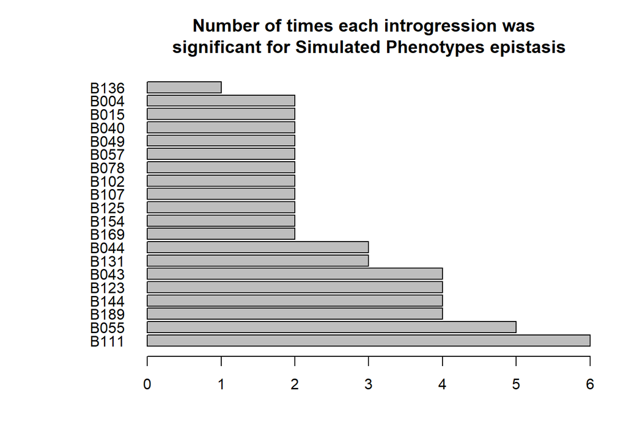

```r
P1 <- unlist(strsplit(as.character(orderedNoNa$Group.1),split="X"))[seq(1,2*nrow(orderedNoNa),2)]
P2 <- unlist(strsplit(as.character(orderedNoNa$Group.1),split="X"))[seq(2,2*nrow(orderedNoNa),2)]
orderedNoNa$P1 <- P1
orderedNoNa$P2 <- P2
orderedNoNa$Sig <- rep("FALSE",nrow(orderedNoNa))
orderedNoNa$Sig[which(col=="red")] <- TRUE
sigIntrogressions <- c(orderedNoNa$P1[which(orderedNoNa$Sig == T)],orderedNoNa$P2[which(orderedNoNa$Sig == T)])
par(las=1)
par(mar=c(5,8,4,2))

if(length(orderedNoNa$Sig[which(orderedNoNa$Sig == "TRUE")]) != 0){
barplot(table(sigIntrogressions)[rev(order(table(sigIntrogressions)))],horiz=T,main=paste("Number of times each introgression was \n significant for", trait,"epistasis", sep=" "))

png("heritability_0.7_1qtl_counts.png")
par(las=1)
par(mar=c(5,8,4,2))
barplot(table(sigIntrogressions)[rev(order(table(sigIntrogressions)))],horiz=T,main=paste("Number of times each introgression was \n significant for", trait,"epistasis", sep=" "))
dev.off()}
```